# 利用logistic回归分析工业污泥干燥装置的改进策略

Tao

2022/3/21

## Sludge 数据集

该数据集来源于工业期刊 Journal of Process Control, 2012, vol. 22, 1387 – 1396。

背景是欧洲的生物废水处理工业。废水处理会产生大量的污泥，为了减少运输和焚烧成本，需要对污泥进行脱水干燥处理。污泥的一个特点是在干燥过程中变成粘性物质，从而堵塞干燥装置。一家比利时公司的污水处理厂使用封闭干燥系统来干燥污泥，由于干燥器污垢问题，需要定期停工以进行维护。我们想要改进此问题。

**SVI** (sludge volume index，污泥体积指数) 用于衡量污泥沉降性，是在实验室沉淀池中沉淀30分钟后每克污泥所占的体积(毫升)：

- 1 = < 60 ml/g 2 = > 60 ml/g.

**sludgefd** 向污泥中加入的添加剂：

- 1 = 不添加絮凝剂 2 = 添加絮凝剂 3 = 直接加入聚氯化铝.

- 1 = low 2 = medium 3 = high

**fouled** 干燥机是否被堵塞： * Y = yes N = no

## Coding

首先读取数据

```r
df1 = read.table("sludge.data", header = TRUE,colClasses = c("factor","factor","factor","character"))
str(df1)
```

```
## 'data.frame':    1727 obs. of  4 variables:
##  $ SVI     : Factor w/ 2 levels "1","2": 1 1 1 1 1 1 1 1 1 1 ...
##  $ sludgefd: Factor w/ 3 levels "1","2","3": 1 1 1 1 1 1 1 1 1 1 ...
##  $ claydose: Factor w/ 3 levels "1","2","3": 3 3 2 2 2 2 2 2 2 2 ...
##  $ fouled  : chr  "N" "N" "N" "N" ...
```

fouled 是 character，转化为logical

```r
df1$fouled=as.logical(df1$fouled=="Y")
head(df1)
```

```
##   SVI sludgefd claydose fouled
## 1   1        1        3  FALSE
## 2   1        1        3  FALSE
## 3   1        1        2  FALSE
## 4   1        1        2  FALSE
## 5   1        1        2  FALSE
## 6   1        1        2  FALSE
```

```r
summary(df1)
```

```
##  SVI      sludgefd claydose   fouled
##  1:1324   1: 131   1:862    Mode :logical
##  2: 403   2:1330   2:675    FALSE:1486
##           3: 266   3:190    TRUE :241
```

## 2

他们都是factor,直接使用mosaic plot 单独观察每一变量

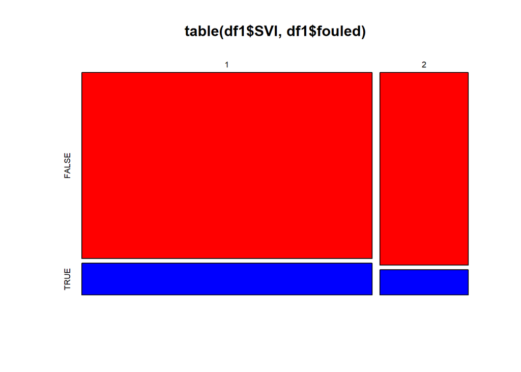

```r
mosaicplot(table(df1$SVI, df1$fouled),col=c("red","blue"))
```

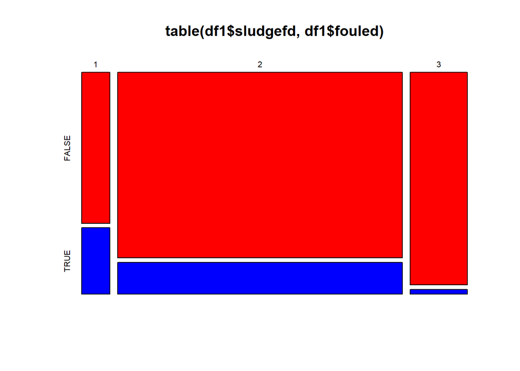

```r
mosaicplot(table(df1$sludgefd, df1$fouled),col=c("red","blue"))
```

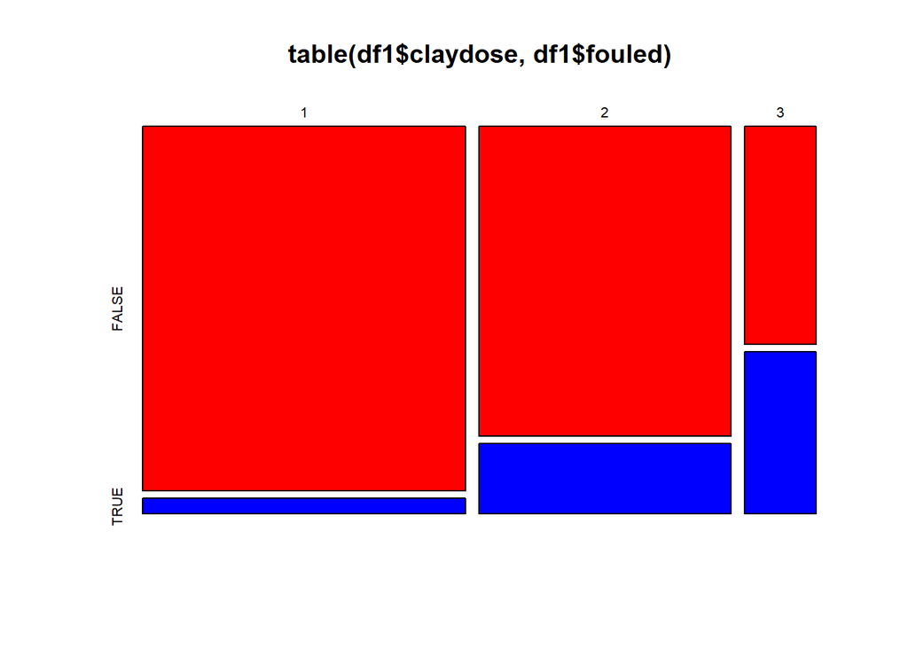

```r
mosaicplot(table(df1$claydose, df1$fouled),col=c("red","blue"))
```

由图可以看出：

- SVI 直观上与fouled没有明显关系。
- sludgefd（添加剂）有降低堵塞率的效果。
- 但与此同时，堵塞可能性随添加剂数量变多而升高。

## 3

```r
table(df1$fouled, df1$claydose)
```

```
##
##           1   2   3
##   FALSE 827 550 109
##   TRUE   35 125  81
```

**(a) The probability of fouling when the level of clay dosing is high.**

```r
(p=81/(109+81))
```

```
## [1] 0.4263158
```

**(b) The odds of fouling when the level of clay dosing is high.**

```r
(odds1=p/(1-p))
```

```
## [1] 0.7431193
```

**(c) The odds ratio that compares the odds of fouling when the level of clay dosing is high to that when it is low.**

```r
(827*81)/(35*109)
```

```
## [1] 17.55885
```

## 4

```r
sludge.glm = glm(fouled~claydose, family = binomial, data = df1)
summary(sludge.glm)
```

```
##
## Call:
## glm(formula = fouled ~ claydose, family = binomial, data = df1)
##
## Deviance Residuals:
##     Min       1Q   Median       3Q      Max
## -1.0542  -0.6400  -0.2879  -0.2879   2.5314
##
## Coefficients:
##             Estimate Std. Error z value Pr(>|z|)
## (Intercept)  -3.1625     0.1725 -18.330   <2e-16 ***
## claydose2     1.6809     0.1990   8.448   <2e-16 ***
## claydose3     2.8656     0.2265  12.653   <2e-16 ***
## ---
## Signif. codes:  0 '***' 0.001 '**' 0.01 '*' 0.05 '.' 0.1 ' ' 1
##
## (Dispersion parameter for binomial family taken to be 1)
##
##     Null deviance: 1395.9  on 1726  degrees of freedom
## Residual deviance: 1199.0  on 1724  degrees of freedom
## AIC: 1205
##
## Number of Fisher Scoring iterations: 5
```

```r
coef1=coef(sludge.glm)
```

We can see that they are basicially the same from the calculation below

**a**

```r
dftemp= data.frame(claydose=factor(3))
(pred_high=predict(sludge.glm,dftemp,type="response"))
```

```
##         1
## 0.4263158
```

**b**

```r
exp(coef1[1] + coef1[3])
```

```
## (Intercept)
##   0.7431193
```

**c**

```r
exp(coef1[1] + coef1[3]) / exp(coef1[1])
```

```
## (Intercept)
##    17.55884
```

## 5

**a** The fitted model has basically no difference with null model, bad model. So SVI is not directly related to fouling

```r
sludgeS.glm = glm(fouled~SVI, family = binomial, data = df1)
summary(sludgeS.glm)
```

```
##
## Call:
## glm(formula = fouled ~ SVI, family = binomial, data = df1)
##
## Deviance Residuals:
##     Min       1Q   Median       3Q      Max
## -0.5629  -0.5629  -0.5629  -0.4980   2.0731
##
## Coefficients:
##             Estimate Std. Error z value Pr(>|z|)
## (Intercept) -1.76211    0.07771 -22.674   <2e-16 ***
## SVI2        -0.26267    0.17356  -1.513     0.13
## ---
## Signif. codes:  0 '***' 0.001 '**' 0.01 '*' 0.05 '.' 0.1 ' ' 1
##
## (Dispersion parameter for binomial family taken to be 1)
##
##     Null deviance: 1395.9  on 1726  degrees of freedom
## Residual deviance: 1393.5  on 1725  degrees of freedom
## AIC: 1397.5
##
## Number of Fisher Scoring iterations: 4
```

**b** It’s much better when we take all regressors. From the anova table we can see that SVI is not directly related to fouling, but it can be useful after effected by the other regressors.

```r
sludgeSSC.glm = glm(fouled~SVI + sludgefd + claydose, family = binomial, data = df1)
summary(sludgeSSC.glm)
```

```
##
## Call:
## glm(formula = fouled ~ SVI + sludgefd + claydose, family = binomial,
##     data = df1)
##
## Deviance Residuals:
##     Min       1Q   Median       3Q      Max
## -1.9121  -0.5374  -0.2952  -0.1629   2.9424
##
## Coefficients:
##             Estimate Std. Error z value Pr(>|z|)
## (Intercept)  -1.8622     0.2489  -7.481 7.39e-14 ***
## SVI2         -1.5449     0.2066  -7.477 7.62e-14 ***
## sludgefd2    -1.2491     0.2387  -5.234 1.66e-07 ***
## sludgefd3    -2.4532     0.4741  -5.174 2.29e-07 ***
## claydose2     1.9862     0.2120   9.369  < 2e-16 ***
## claydose3     3.5149     0.2644  13.292  < 2e-16 ***
## ---
## Signif. codes:  0 '***' 0.001 '**' 0.01 '*' 0.05 '.' 0.1 ' ' 1
##
## (Dispersion parameter for binomial family taken to be 1)
##
##     Null deviance: 1395.9  on 1726  degrees of freedom
## Residual deviance: 1094.2  on 1721  degrees of freedom
## AIC: 1106.2
##
## Number of Fisher Scoring iterations: 6
```

```r
print("------------------------------------------------------------------")
```

```
## [1] "------------------------------------------------------------------"
```

```r
anova(sludgeSSC.glm,test="Chisq")
```

```
## Analysis of Deviance Table
##
## Model: binomial, link: logit
##
## Response: fouled
##
## Terms added sequentially (first to last)
##
##
##          Df Deviance Resid. Df Resid. Dev Pr(>Chi)
## NULL                      1726     1395.9
## SVI       1    2.382      1725     1393.5   0.1228
## sludgefd  2   72.865      1723     1320.7   <2e-16 ***
## claydose  2  226.472      1721     1094.2   <2e-16 ***
## ---
## Signif. codes:  0 '***' 0.001 '**' 0.01 '*' 0.05 '.' 0.1 ' ' 1
```

```r
print("------------------------------------------------------------------")
```

```
## [1] "------------------------------------------------------------------"
```

```r
anova(glm(fouled~sludgefd + claydose +SVI, family = binomial, data = df1),test="Chisq")
```

```
## Analysis of Deviance Table
##
## Model: binomial, link: logit
##
## Response: fouled
##
## Terms added sequentially (first to last)
##
##
##          Df Deviance Resid. Df Resid. Dev  Pr(>Chi)
## NULL                      1726     1395.9
## sludgefd  2   68.655      1724     1327.2 1.235e-15 ***
## claydose  2  165.980      1722     1161.3 < 2.2e-16 ***
## SVI       1   67.083      1721     1094.2 2.603e-16 ***
## ---
## Signif. codes:  0 '***' 0.001 '**' 0.01 '*' 0.05 '.' 0.1 ' ' 1
```